# Titanic KNN (English version)

Vanessa Herrada Saavedra

# 1 Context and Exploratory Analysis

**The Titanic Disaster: A Historical Perspective**

The RMS Titanic, an impressive British ocean liner, held the title of being the largest passenger ship of its time. However, its maiden voyage was marred by an unprecedented tragedy. In the fateful early morning of April 15, 1912, while en route to New York, the RMS Titanic collided with an iceberg and quickly sank into the icy waters of the North Atlantic. This tragic event claimed the lives of 1,496 people out of the 2,208 on board, despite the ship having a theoretical capacity to accommodate up to 3,547 passengers. Survivors were rescued hours later by the transatlantic liner RMS Carpathia, in a rescue operation that moved the entire world.

## 1.1 Objective

The fundamental purpose of this study lies in predicting the survival of passengers involved in the Titanic disaster, using machine learning techniques, specifically through the k-nearest neighbors algorithm.

This challenge, extracted from: Kaggle (https://www.kaggle.com/competitions/titanic/overview), poses the task of employing machine learning to develop a model capable of predicting which passengers managed to survive the Titanic shipwreck.

```r
# Delete
rm(list = ls())
```

```r
# Packages
if (!require("Amelia")) install.packages("Amelia")
if (!require("C50")) install.packages("C50")
if (!require("doParallel")) install.packages("doParallel")
if (!require("dplyr")) install.packages("dplyr")
if (!require("fastDummies")) install.packages("fastDummies")
if (!require("ggplot2")) install.packages("ggplot2")
if (!require("ggridges")) install.packages("ggridges")
if (!require("ggthemes")) install.packages("ggthemes")
if (!require("glue")) install.packages("glue")
if (!require("hrbrthemes")) install.packages("hrbrthemes")
if (!require("IRdisplay")) install.packages("IRdisplay")
if (!require("kknn")) install.packages("kknn")
if (!require("lubridate")) install.packages("lubridate")
if (!require("naniar")) install.packages("naniar")
if (!require("parallel")) install.packages("parallel")
if (!require("parsnip")) install.packages("parsnip")
if (!require("recipes")) install.packages("recipes")
if (!require("rlang")) install.packages("rlang")
if (!require("rpart")) install.packages("rpart")
if (!require("rpart.plot")) install.packages("rpart.plot")
if (!require("rsample")) install.packages("rsample")
if (!require("scales")) install.packages("scales")
if (!require("showtext")) install.packages("showtext")
if (!require("skimr")) install.packages("skimr")
if (!require("themis")) install.packages("themis")
if (!require("tibble")) install.packages("tibble")
if (!require("tidymodels")) install.packages("tidymodels")
if (!require("tidyverse")) install.packages("tidyverse")
if (!require("vip")) install.packages("vip")
if (!require("viridis")) install.packages("viridis")
if (!require("workflows")) install.packages("workflows")

library(Amelia)
library(C50)
library(doParallel)
library(dplyr)
library(fastDummies)
library(ggplot2)
library(ggridges)
library(ggthemes)
library(glue)
library(hrbrthemes)
library(IRdisplay)
library(kknn)
library(lubridate)
library(naniar)
library(parallel)
library(parsnip)
library(recipes)
library(rlang)
library(rpart)
library(rpart.plot)
library(rsample)
library(scales)
library(showtext)
library(skimr)
library(themis)
library(tibble)
library(tidymodels)
library(tidyverse)
library(vip)
library(viridis)
library(workflows)

font_add_google("Lobster Two", "lobstertwo")
font_add_google("Poppins", "poppins")
showtext_auto()
```

## 1.2 Data loading

The data was obtained from the website: https://www.kaggle.com/competitions/titanic/overview previously mentioned.

```r
# Dataset
titanic_train <- read.csv("C:/Users/vanny/OneDrive/Escritorio/Portfolio/titanic_train.csv")
titanic_test <- read.csv("C:/Users/vanny/OneDrive/Escritorio/Portfolio/titanic_test.csv")
```

## 1.3 Exploratory Analysis

In general terms, we have a dataset divided into two parts: one intended for model training, called “train,” and another for evaluation, called “test.” The “train” set consists of 891 observations and 11 variables, in addition to the target variable ‘Survived,’ while the “test” set contains 418 observations, with the same 11 variables but excluding the target variable.

The variables provide the following information:

- Survived: Represents whether the passenger survived (1) or not (0). This is the target variable we seek to predict.
- PassengerId: Unique identification of each crew member, simply being an identification number.
- Pclass: Indicates the class in which the passengers traveled: first, second, or third class.
- Name: Passenger’s name.
- Sex: Passenger’s gender, being male or female. To simplify the analysis, it could be converted into a binary variable.
- Age: Passenger’s age in years.
- SibSp: Number of siblings or spouses aboard the Titanic.
- Parch: Number of parents or children aboard the Titanic. For children traveling only with their nanny, this variable is 0.
- Ticket: Ticket number.
- Fare: Ticket cost.
- Cabin: Cabin number, with alphanumeric values, but with a significant amount of null values.
- Embarked: Port of embarkation, with the following designations:
- C=Cherbourg
- Q=Queenstown
- S=Southampton.

### 1.3.1 Exploratory Analysis of the “Train” Set

An analysis of the “train” set is conducted to examine the relationships between the target variable and the other variables:

It is observed that only 38% of the crew members managed to survive, which amounts to 342 people, while the remaining 62% perished, totaling 549 individuals.

```r
# Survivors
titanic_train %>% count(Survived) %>% mutate(porc=100*n/sum(n))
```

```
##   Survived   n     porc
## 1        0 549 61.61616
## 2        1 342 38.38384
```

**Pclass vs Survived**

For the deceased passengers (Survived = 0):

- The most represented class is the third class (Pclass = 3) with 372 passengers, constituting approximately 67.76% of the total deceased.
- It is followed by the second class (Pclass = 2) with 97 passengers, representing around 17.67% of the total deceased.
- The first class (Pclass = 1) has the fewest deceased, with 80 passengers, corresponding to 14.57% of the total deceased.

For the surviving passengers (Survived = 1):

- The first class (Pclass = 1) has the highest number of survivors, with 136 passengers, representing approximately 39.77% of the total survivors.
- Next, the third class (Pclass = 3) has 119 survivors, constituting around 34.80% of the total survivors.
- The second class (Pclass = 2) has the fewest survivors, with 87 passengers, representing approximately 25.44% of the total survivors.

This analysis reveals the distribution of deceased and surviving passengers according to their class on the Titanic. There is a clear disparity in survival rates among the different classes, with the first class having the highest proportion of survivors and the third class the lowest proportion.

```r
# Survived vs Pclass
titanic_train %>% group_by(Survived) %>% count(Pclass) %>%  mutate("Percentage (%)"=100*n/sum(n))
```

```
## # A tibble: 6 × 4
## # Groups:   Survived [2]
##   Survived Pclass     n `Percentage (%)`
##      <int>  <int> <int>            <dbl>
## 1        0      1    80             14.6
## 2        0      2    97             17.7
## 3        0      3   372             67.8
## 4        1      1   136             39.8
## 5        1      2    87             25.4
## 6        1      3   119             34.8
```

The graph is shown below:

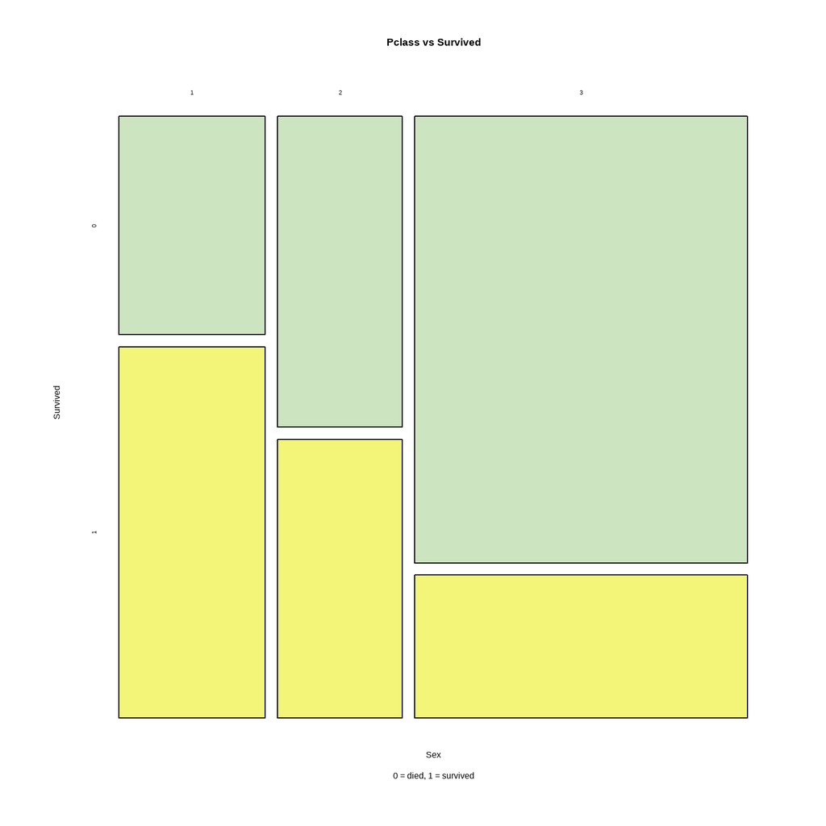

```r
# Graph Survived vs Pclass
graph_pclass <- mosaicplot(table(titanic_train$Pclass, titanic_train$Survived),
  col = c("#CDE4C0", "#F3F579"),
  xlab = "Sex",
  ylab = "Survived",
  main = "Pclass vs Survived",
  sub = "0 = died, 1 = survived")
```

**Sex vs Survived**

Among the survivors, 68% were women and 32% were men. In contrast, among the deceased, 15% were women and 85% were men. These data clearly reflect a pattern suggesting prioritization in the rescue of women, which aligns with the historical practice of giving preference to the evacuation of women and children in maritime emergency situations.

This behavior can be observed in the following table:

```r
# Survived vs Sex
titanic_train %>% group_by(Survived) %>% count(Sex) %>%  mutate("Percentage (%)"=100*n/sum(n))
```

```
## # A tibble: 4 × 4
## # Groups:   Survived [2]
##   Survived Sex        n `Percentage (%)`
##      <int> <chr>  <int>            <dbl>
## 1        0 female    81             14.8
## 2        0 male     468             85.2
## 3        1 female   233             68.1
## 4        1 male     109             31.9
```

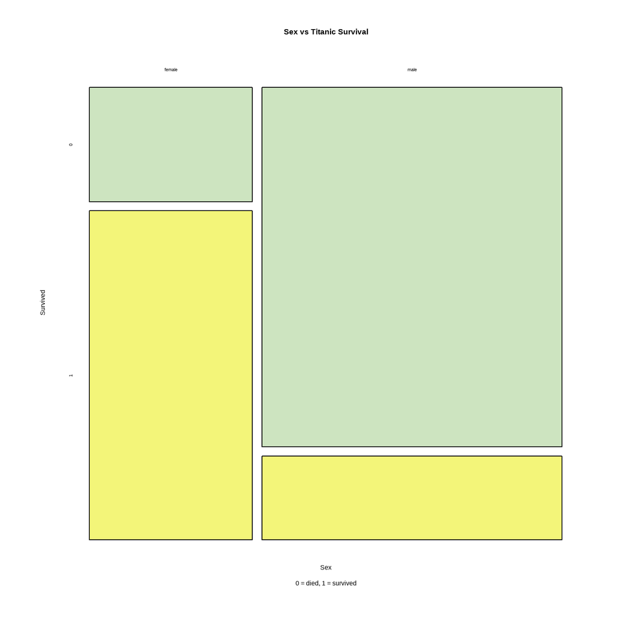

```r
# Graph Survived vs Sex
graph_sex <- mosaicplot(table(titanic_train$Sex, titanic_train$Survived),
  col = c("#CDE4C0", "#F3F579"),
  xlab = "Sex",
  ylab = "Survived",
  main = "Sex vs Titanic Survival",
  sub = "0 = died, 1 = survived")
```

**Age vs Survived**

The analysis of survival distribution by age groups reveals a series of significant patterns in the Titanic tragedy:

```r
# Survived vs Age
tabla_ages <- titanic_train %>%
  mutate(age_group = cut(Age, breaks = seq(0, 100, by = 10), right = FALSE, include.lowest = TRUE)) %>%
  group_by(age_group, Survived) %>%
  summarise(n = n()) %>%
  group_by(age_group) %>%
  mutate("Percentage (%)" = 100 * n / sum(n))

print(tabla_ages)
```

```
## # A tibble: 18 × 4
## # Groups:   age_group [10]
##    age_group Survived     n `Percentage (%)`
##    <fct>        <int> <int>            <dbl>
##  1 [0,10)           0    24             38.7
##  2 [0,10)           1    38             61.3
##  3 [10,20)          0    61             59.8
##  4 [10,20)          1    41             40.2
##  5 [20,30)          0   143             65
##  6 [20,30)          1    77             35
##  7 [30,40)          0    94             56.3
##  8 [30,40)          1    73             43.7
##  9 [40,50)          0    55             61.8
## 10 [40,50)          1    34             38.2
## 11 [50,60)          0    28             58.3
## 12 [50,60)          1    20             41.7
## 13 [60,70)          0    13             68.4
## 14 [60,70)          1     6             31.6
## 15 [70,80)          0     6            100
## 16 [80,90)          1     1            100
## 17 <NA>             0   125             70.6
## 18 <NA>             1    52             29.4
```

The following graph shows the relationship “Age vs Survived”:

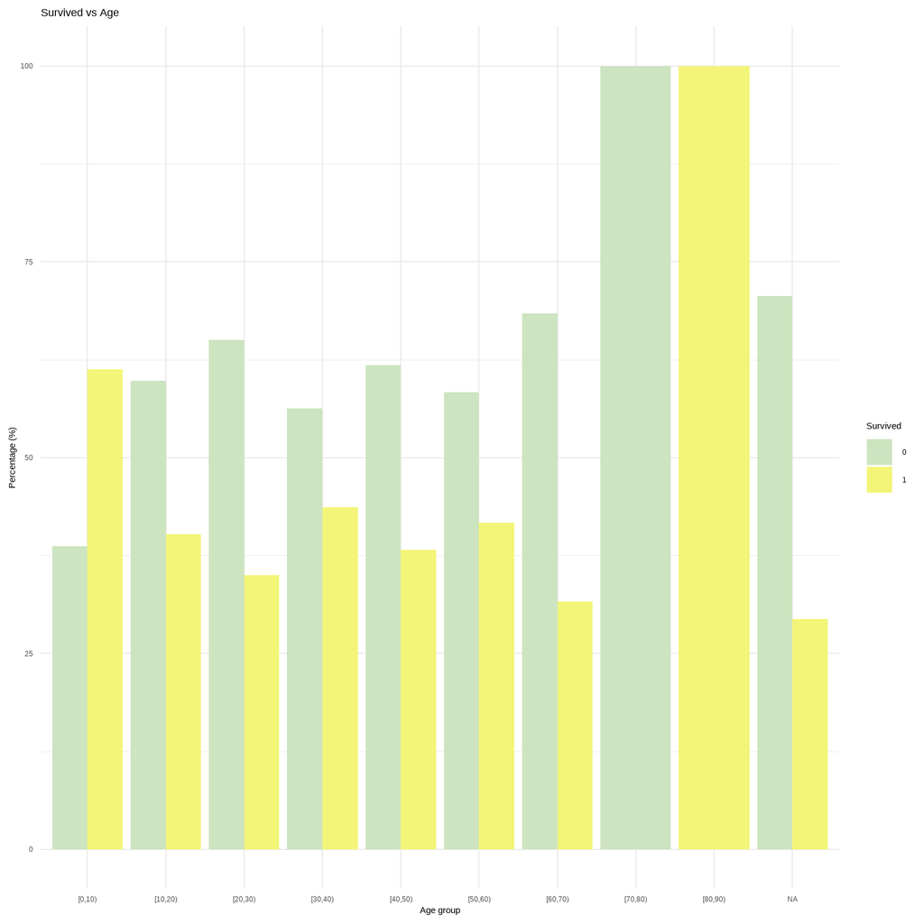

```r
# Graph Survived vs Age
graph_age <- ggplot(tabla_ages, aes(x = age_group, y = `Percentage (%)`, fill = as.factor(Survived))) +
  geom_bar(stat = "identity", position = "dodge") +
  labs(x = "Age group", y = "Percentage (%)", fill = "Survived") +
  ggtitle("Survived vs Age") +
  scale_fill_manual(values = c("#CDE4C0", "#F3F579")) +
  theme_minimal()

print(graph_age)
```

**SibSp vs Survived**

Among all the deceased, the following distribution is observed in relation to the number of siblings/spouses aboard:

- Traveling without siblings/spouses: They represent 72.5% of the total.
- Traveling with 1 sibling/spouse: They constitute 17.7% of the total.
- Traveling with 2 siblings/spouses: They comprise 2.8% of the total.
- Traveling with 3 siblings/spouses: They represent 2.2% of the total.
- Traveling with 4 siblings/spouses: They encompass 2.7% of the total.
- Traveling with 5 siblings/spouses: They form 0.9% of the total.
- Traveling with 8 siblings/spouses: They represent 1.3% of the total.

On the other hand, regarding the individuals who survived, they are distributed as follows according to the number of siblings/spouses aboard:

- Traveling without siblings/spouses: They constitute 61.5% of the total survivors.
- Traveling with 1 sibling/spouse: They represent 32.8%.
- Traveling with 2 siblings/spouses: They encompass 3.8%.
- Traveling with 3 siblings/spouses: They form 1.17%.
- Traveling with 4 siblings/spouses: They represent 0.9%.

```r
# Survived vs SibSp
titanic_train %>% group_by(Survived) %>% count(SibSp) %>%  mutate("Percentage (%)"=100*n/sum(n))
```

```
## # A tibble: 12 × 4
## # Groups:   Survived [2]
##    Survived SibSp     n `Percentage (%)`
##       <int> <int> <int>            <dbl>
##  1        0     0   398           72.5
##  2        0     1    97           17.7
##  3        0     2    15            2.73
##  4        0     3    12            2.19
##  5        0     4    15            2.73
##  6        0     5     5            0.911
##  7        0     8     7            1.28
##  8        1     0   210           61.4
##  9        1     1   112           32.7
## 10        1     2    13            3.80
## 11        1     3     4            1.17
## 12        1     4     3            0.877
```

This visualization provides a clear perspective of the “Survived vs SibSp (siblings/spouses)” relationship:

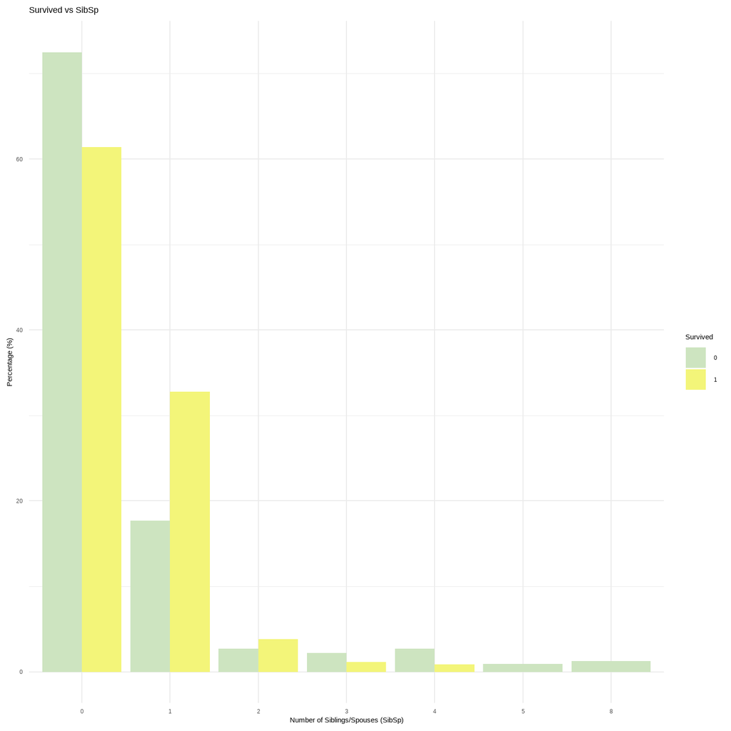

```r
# Graph Survived vs SibSp
titanic_train %>%
  group_by(Survived, SibSp) %>%
  summarise(n = n()) %>%
  mutate("Percentage (%)" = 100 * n / sum(n)) %>%
  ggplot(aes(x = as.factor(SibSp), y = `Percentage (%)`, fill = as.factor(Survived))) +
  geom_bar(stat = "identity", position = "dodge") +
  labs(x = "Number of Siblings/Spouses (SibSp)", y = "Percentage (%)", fill = "Survived") +
  ggtitle("Survived vs SibSp") +
  scale_fill_manual(values = c("#CDE4C0", "#F3F579")) +
  theme_minimal()
```

**Parch vs Survived**

For the passengers who did not survive:

- 81.06% of them did not have parents/children aboard.
- 9.65% had 1 parent/child aboard.
- 7.29% had 2 parents/children aboard.
- The rest had between 3 and 6 parents/children aboard, with lower percentages.

For the passengers who survived:

- 68.13% of them did not have parents/children aboard.
- 19.01% had 1 parent/child aboard.
- 11.70% had 2 parents/children aboard.
- Only a small fraction had 3 or 5 parents/children aboard.

```r
# Survived vs Parch
titanic_train %>% group_by(Survived) %>% count(Parch) %>%  mutate("Percentage (%)"=100*n/sum(n))
```

```
## # A tibble: 12 × 4
## # Groups:   Survived [2]
##    Survived Parch     n `Percentage (%)`
##       <int> <int> <int>            <dbl>
##  1        0     0   445           81.1
##  2        0     1    53            9.65
##  3        0     2    40            7.29
##  4        0     3     2            0.364
##  5        0     4     4            0.729
##  6        0     5     4            0.729
##  7        0     6     1            0.182
##  8        1     0   233           68.1
##  9        1     1    65           19.0
## 10        1     2    40           11.7
## 11        1     3     3            0.877
## 12        1     5     1            0.292
```

Below is the corresponding graph:

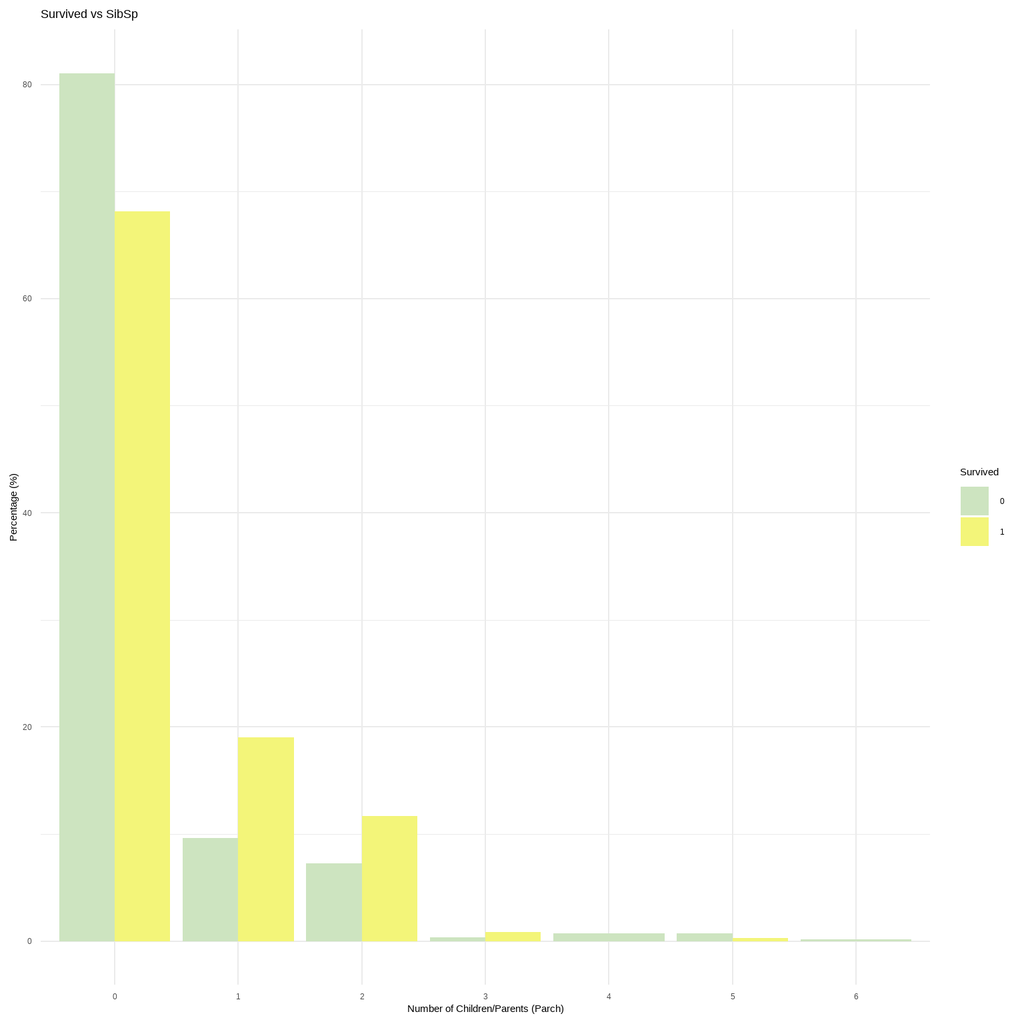

```r
# Graph Survived vs Parch
titanic_train %>%
  group_by(Survived, Parch) %>%
  summarise(n = n()) %>%
  mutate("Percentage (%)" = 100 * n / sum(n)) %>%
  ggplot(aes(x = as.factor(Parch), y = `Percentage (%)`, fill = as.factor(Survived))) +
  geom_bar(stat = "identity", position = "dodge") +
  labs(x = "Number of Children/Parents (Parch)", y = "Percentage (%)", fill = "Survived") +
  ggtitle("Survived vs SibSp") +
  scale_fill_manual(values = c("#CDE4C0", "#F3F579")) +
  theme_minimal()
```

**Fare vs Survived**

This analysis provides a detailed insight into how the ticket fare correlates with survival rates during the Titanic tragedy.

```r
# Survived vs Age
tabla_fare <- titanic_train %>%
  mutate(fare_group = cut(Fare, breaks = seq(0, 550, by = 50), right = FALSE, include.lowest = TRUE)) %>%
  group_by(fare_group, Survived) %>%
  summarise(n = n()) %>%
  group_by(fare_group) %>%
  mutate("Percentage (%)" = 100 * n / sum(n))

print(tabla_fare)
```

```
## # A tibble: 13 × 4
## # Groups:   fare_group [7]
##    fare_group Survived     n `Percentage (%)`
##    <fct>         <int> <int>            <dbl>
##  1 [0,50)            0   497             68.1
##  2 [0,50)            1   233             31.9
##  3 [50,100)          0    38             35.2
##  4 [50,100)          1    70             64.8
##  5 [100,150)         0     5             20.8
##  6 [100,150)         1    19             79.2
##  7 [150,200)         0     3             33.3
##  8 [150,200)         1     6             66.7
##  9 [200,250)         0     4             36.4
## 10 [200,250)         1     7             63.6
## 11 [250,300)         0     2             33.3
## 12 [250,300)         1     4             66.7
## 13 [500,550]         1     3            100
```

The following graph shows the “Fare vs Survived” relationship:

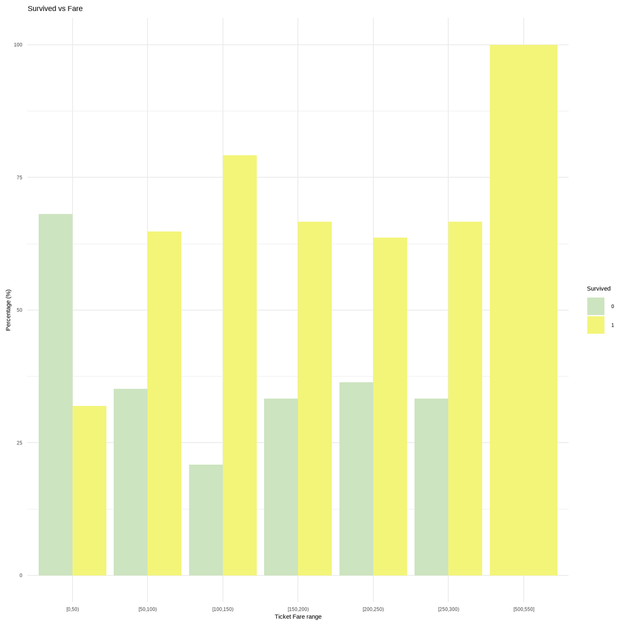

```r
# Gráfica Survived vs Age
graph_fare <- ggplot(tabla_fare, aes(x = fare_group, y = `Percentage (%)`, fill = as.factor(Survived))) +
  geom_bar(stat = "identity", position = "dodge") +
  labs(x = "Ticket Fare range", y = "Percentage (%)", fill = "Survived") +
  ggtitle("Survived vs Fare") +
  scale_fill_manual(values = c("#CDE4C0", "#F3F579")) +
  theme_minimal()

print(graph_fare)
```

**Embarked vs Survived**

Of the 100% of the deceased:

- 13.66% of passengers embarked at the port of Cherbourg.
- 8.56% of passengers embarked at the port of Queenstown.
- 77.8% of passengers embarked at the port of Southampton.

Of the 100% of the survivors:

- 27.19% of passengers embarked at the port of Cherbourg.
- 8.77% of passengers embarked at the port of Queenstown.
- 63.45% of passengers embarked at the port of Southampton.
- There are 2 passengers for whom it is unknown where they embarked.

The port of Southampton is where the highest number of crew members embarked, and the majority of both the deceased and survivors used this port to board.

```r
# Survived vs Embarked
titanic_train %>% group_by(Survived) %>% count(Embarked) %>%  mutate("Percentage (%)"=100*n/sum(n))
```

```
## # A tibble: 7 × 4
## # Groups:   Survived [2]
##   Survived Embarked     n `Percentage (%)`
##      <int> <chr>    <int>            <dbl>
## 1        0 "C"         75           13.7
## 2        0 "Q"         47            8.56
## 3        0 "S"        427           77.8
## 4        1 ""           2            0.585
## 5        1 "C"         93           27.2
## 6        1 "Q"         30            8.77
## 7        1 "S"        217           63.5
```

Below is the graph “Survived vs Embarked”:

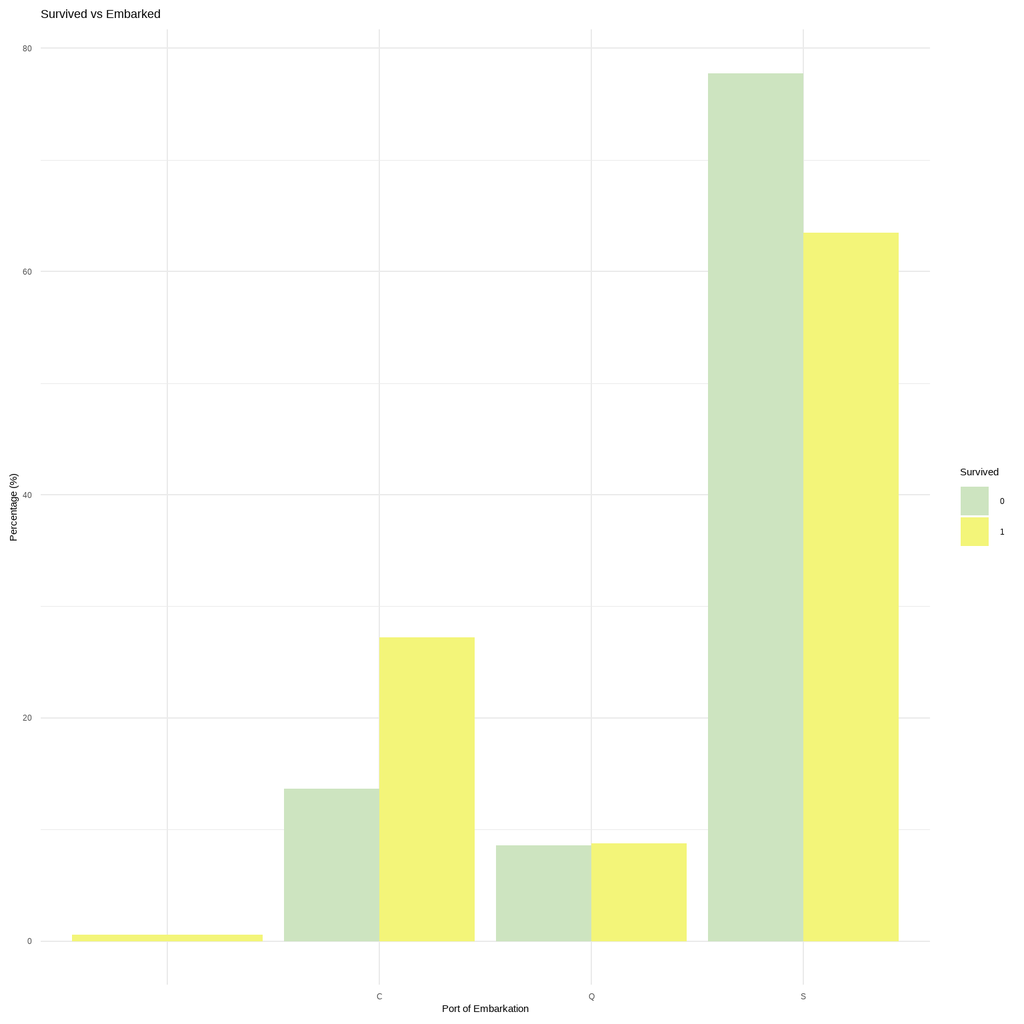

```r
# Graph Survived vs Embarked
titanic_train %>%
  group_by(Survived, Embarked) %>%
  summarise(n = n()) %>%
  mutate("Percentage (%)" = 100 * n / sum(n)) %>%
  ggplot(aes(x = as.factor(Embarked), y = `Percentage (%)`, fill = as.factor(Survived))) +
  geom_bar(stat = "identity", position = "dodge") +
  labs(x = "Port of Embarkation", y = "Percentage (%)", fill = "Survived") +
  ggtitle("Survived vs Embarked") +
  scale_fill_manual(values = c("#CDE4C0", "#F3F579")) +
  theme_minimal()
```

**Fare vs PClass**

When examining the relationship between the ticket fare (“Fare”) and the passenger class (“PClass”), it is observed that those who paid higher fares generally traveled in the first class. However, there are also cases where some passengers in the second and third class paid fares similar to those in the first class.

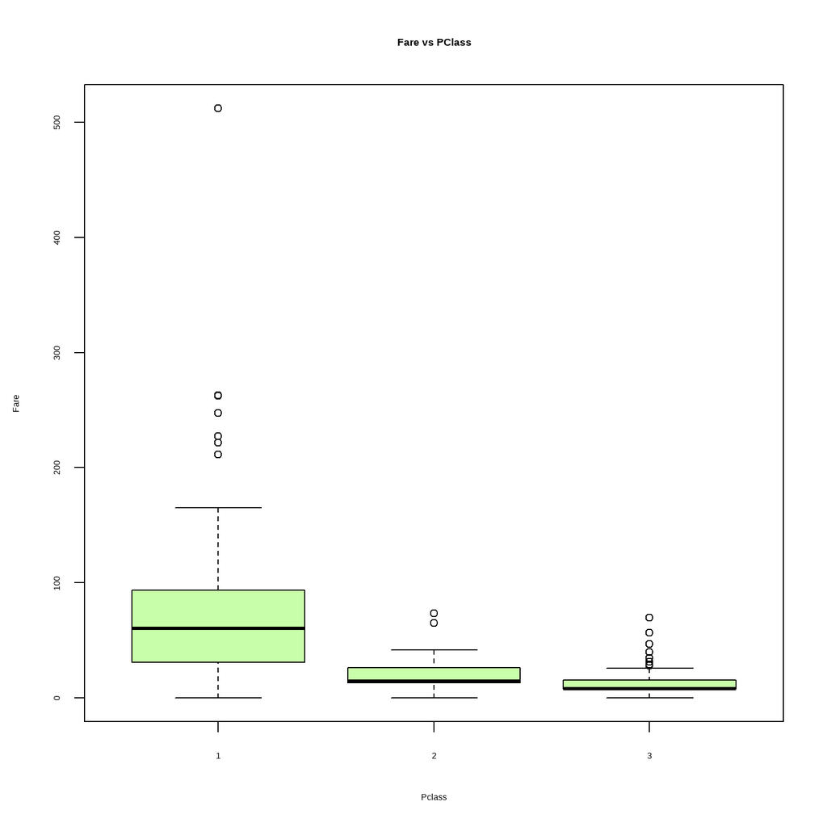

```r
# Fare boxplot
boxplot(Fare ~ Pclass, data = titanic_train,
        main = 'Fare vs PClass',ylab = 'Fare', col = '#C8FEA9')
```

```r
titanic_train2 <- titanic_train[, -2]
view(titanic_train2)

full <- bind_rows(titanic_train2, titanic_test)
view(full)
```

Continuing with an exploratory analysis of all the data, including the “train” and “test” sets, where the “Survived” column is removed since the “test” set does not include it. In total, there are 11 columns and 1309 crew members.

It is observed that R is misclassifying the variables, so they will need to be reclassified correctly.

On the other hand, ‘Age’ has 263 missing values.

In the case of ‘Embarked’, it does not mark missing values, R is categorizing it incorrectly, but upon closer inspection of the data, it is evident that there are missing values.

```r
# Numerical summary
full %>% skim()
```

Data summary

| Name | Piped data |
| --- | --- |
| Number of rows | 1309 |
| Number of columns | 11 |
| _______________________ |  |
| Column type frequency: |  |
| character | 5 |
| numeric | 6 |
| ________________________ |  |
| Group variables | None |

**Variable type: character**

| skim_variable | n_missing | complete_rate | min | max | empty | n_unique | whitespace |
| --- | --- | --- | --- | --- | --- | --- | --- |
| Name | 0 | 1 | 12 | 82 | 0 | 1307 | 0 |
| Sex | 0 | 1 | 4 | 6 | 0 | 2 | 0 |
| Ticket | 0 | 1 | 3 | 18 | 0 | 929 | 0 |
| Cabin | 0 | 1 | 0 | 15 | 1014 | 187 | 0 |
| Embarked | 0 | 1 | 0 | 1 | 2 | 4 | 0 |

**Variable type: numeric**

| skim_variable | n_missing | complete_rate | mean | sd | p0 | p25 | p50 | p75 | p100 | hist |
| --- | --- | --- | --- | --- | --- | --- | --- | --- | --- | --- |
| PassengerId | 0 | 1.0 | 655.00 | 378.02 | 1.00 | 328.0 | 655.00 | 982.00 | 1309.00 | ▇▇▇▇▇ |
| Pclass | 0 | 1.0 | 2.29 | 0.84 | 1.00 | 2.0 | 3.00 | 3.00 | 3.00 | ▃▁▃▁▇ |
| Age | 263 | 0.8 | 29.88 | 14.41 | 0.17 | 21.0 | 28.00 | 39.00 | 80.00 | ▂▇▅▂▁ |
| SibSp | 0 | 1.0 | 0.50 | 1.04 | 0.00 | 0.0 | 0.00 | 1.00 | 8.00 | ▇▁▁▁▁ |
| Parch | 0 | 1.0 | 0.39 | 0.87 | 0.00 | 0.0 | 0.00 | 0.00 | 9.00 | ▇▁▁▁▁ |
| Fare | 1 | 1.0 | 33.30 | 51.76 | 0.00 | 7.9 | 14.45 | 31.27 | 512.33 | ▇▁▁▁▁ |

# 2 Data transformation

Next, the data is partitioned and transformed (recipe and baking) before proceeding to work on the models.

## 2.1 Partition

To begin working with the data, a stratified partition is performed using the “train” data, and a check of the levels is conducted to confirm that the proportions of survivors are very similar in both subsets.

```r
titanic_train$Survived <- factor(titanic_train$Survived)

# 80-20% Partition - 'Survived'"
set.seed(3615)
titanic_split <- initial_split(titanic_train, strata = Survived, prop = 0.8)
titanic_split
```

```
## <Training/Testing/Total>
## <712/179/891>
```

```r
# Saving Train & Test
titanic_train_train <- training(titanic_split)
titanic_train_test  <- testing(titanic_split)

# Checking levels
titanic_train_train %>% count(Survived) %>% mutate(porc = 100 * n / sum(n))
```

```
##   Survived   n    porc
## 1        0 439 61.6573
## 2        1 273 38.3427
```

```r
titanic_train_test %>% count(Survived) %>% mutate(porc = 100 * n / sum(n))
```

```
##   Survived   n     porc
## 1        0 110 61.45251
## 2        1  69 38.54749
```

## 2.2 Recipe

The recipe named “recipe_titanic” has been created with the purpose of standardizing and preparing the Titanic dataset for future analysis and modeling. The steps performed in this recipe are as follows:

- The variable “Survived” is designated as the target variable for the model.
- Character-type variables are converted into factors to facilitate their handling and analysis.
- It is specified that the identifiers (IDs) are located in the variable “PassengerID”.
- Missing values (NAs) in the dataset are identified and reported to the model.
- For missing values in the “Age” and “Fare” variables, the median is used to impute the missing data.
- For missing values in the “Embarked” variable, the mode method is applied to complete the missing information.
- The variables “Ticket”, “Cabin”, and “Name” are removed from the dataset as they are not considered relevant for analysis.
- Numeric variables are scaled to fit within a range of values between 0 and 1, while nominal variables are converted into binary variables for proper interpretation by the model.

This recipe provides a solid and consistent foundation for data processing in future machine learning models that utilize this Titanic dataset.

```r
# Recipe: Survived vs the rest.
receta_titanic <-

  # Specifying the target variable
  recipe(data = titanic_train_train, Survived ~ .) %>%

  # R isn't reading empty values as null, so we tell it to fill any empty values with NA.
  step_mutate(Embarked=na_if(Embarked, "")) %>%

  # Transforming "character" variables into factors.
  step_mutate(across(c(Sex, Embarked, Pclass), as.factor)) %>%

  # Identifying the IDs
  update_role(PassengerId, new_role = "ID")%>%

  # Imputing the missing values
  step_impute_median(all_numeric_predictors()) %>%
  step_impute_mode(all_nominal_predictors()) %>%

  # Deliting variables: Ticket, Cabin and Name
  step_rm(c(Ticket, Cabin, Name)) %>%

  # Converting to ordinal and binary, as appropriate.
  step_range(all_numeric_predictors(), min=0, max=1) %>%
  step_dummy(all_nominal_predictors())

receta_titanic
```

## 2.3 Baking

The next step involves “baking” the data, once the recipe is ready. This process is carried out for both the training set (Train) and the test set (Test).

```r
# To train
bake(receta_titanic %>% prep(), new_data = NULL)
```

```
## # A tibble: 712 × 12
##    PassengerId    Age SibSp Parch   Fare Survived Pclass_X2 Pclass_X3 Sex_male
##          <int>  <dbl> <dbl> <dbl>  <dbl> <fct>        <dbl>     <dbl>    <dbl>
##  1           1 0.269  0.125 0     0.0142 0                0         1        1
##  2           5 0.433  0     0     0.0157 0                0         1        1
##  3           6 0.345  0     0     0.0165 0                0         1        1
##  4           7 0.672  0     0     0.101  0                0         0        1
##  5           8 0.0168 0.375 0.167 0.0411 0                0         1        1
##  6          14 0.483  0.125 0.833 0.0610 0                0         1        1
##  7          19 0.382  0.125 0     0.0351 0                0         1        0
##  8          21 0.433  0     0     0.0507 0                1         0        1
##  9          25 0.0924 0.375 0.167 0.0411 0                0         1        0
## 10          27 0.345  0     0     0.0141 0                0         1        1
## # ℹ 702 more rows
## # ℹ 3 more variables: Embarked_C <dbl>, Embarked_Q <dbl>, Embarked_S <dbl>
```

```r
# To test
bake(receta_titanic %>% prep(), new_data = titanic_train_test)
```

```
## # A tibble: 179 × 12
##    PassengerId    Age SibSp Parch   Fare Survived Pclass_X2 Pclass_X3 Sex_male
##          <int>  <dbl> <dbl> <dbl>  <dbl> <fct>        <dbl>     <dbl>    <dbl>
##  1           9 0.332  0     0.333 0.0217 1                0         1        0
##  2          13 0.244  0     0     0.0157 0                0         1        1
##  3          15 0.168  0     0     0.0153 0                0         1        0
##  4          17 0.0168 0.5   0.167 0.0568 0                0         1        1
##  5          18 0.345  0     0     0.0254 1                1         0        1
##  6          29 0.345  0     0     0.0154 1                0         1        0
##  7          31 0.496  0     0     0.0541 0                0         0        1
##  8          43 0.345  0     0     0.0154 0                0         1        1
##  9          45 0.231  0     0     0.0154 1                0         1        0
## 10          47 0.345  0.125 0     0.0303 0                0         1        1
## # ℹ 169 more rows
## # ℹ 3 more variables: Embarked_C <dbl>, Embarked_Q <dbl>, Embarked_S <dbl>
```

# 3 KNN Model

We proceed to create the model, which includes the following specifications:

- 10 neighbors will be used to make predictions.
- A greater influence factor will be applied to the nearest neighbors in the prediction (parameter “inv”).
- Euclidean distance will be used as the distance measure (dist_power=2).

```r
knn_model <-
  nearest_neighbor(mode = "classification", neighbors = 10,
                   weight_func = "inv", dist_power = 2) %>%
  set_engine("kknn")
knn_model
```

```
## K-Nearest Neighbor Model Specification (classification)
##
## Main Arguments:
##   neighbors = 10
##   weight_func = inv
##   dist_power = 2
##
## Computational engine: kknn
```

Now, the recipe and the KNN model are combined to create the Workflow.

```r
# Workflow
titanic_wf <-
  workflow() %>%
  add_recipe(receta_titanic) %>%
  add_model(knn_model)
titanic_wf
```

```
## ══ Workflow ════════════════════════════════════════════════════════════════════
## Preprocessor: Recipe
## Model: nearest_neighbor()
##
## ── Preprocessor ────────────────────────────────────────────────────────────────
## 7 Recipe Steps
##
## • step_mutate()
## • step_mutate()
## • step_impute_median()
## • step_impute_mode()
## • step_rm()
## • step_range()
## • step_dummy()
##
## ── Model ───────────────────────────────────────────────────────────────────────
## K-Nearest Neighbor Model Specification (classification)
##
## Main Arguments:
##   neighbors = 10
##   weight_func = inv
##   dist_power = 2
##
## Computational engine: kknn
```

It’s time to implement the Workflow:

```r
# Applying the workflow
titanic_knn_fit <- titanic_wf %>% fit(data = titanic_train_train)
titanic_knn_fit
```

```
## ══ Workflow [trained] ══════════════════════════════════════════════════════════
## Preprocessor: Recipe
## Model: nearest_neighbor()
##
## ── Preprocessor ────────────────────────────────────────────────────────────────
## 7 Recipe Steps
##
## • step_mutate()
## • step_mutate()
## • step_impute_median()
## • step_impute_mode()
## • step_rm()
## • step_range()
## • step_dummy()
##
## ── Model ───────────────────────────────────────────────────────────────────────
##
## Call:
## kknn::train.kknn(formula = ..y ~ ., data = data, ks = min_rows(10,     data, 5), distance = ~2, kernel = ~"inv")
##
## Type of response variable: nominal
## Minimal misclassification: 0.2092697
## Best kernel: inv
## Best k: 10
```

Now the model is applied to the “titanic_train_test” dataset in order to obtain the ROC curve and thus observe the accuracy of the predictions.

```r
# Applying to the test dataset
predict(titanic_knn_fit, titanic_train_test)
```

```
## # A tibble: 179 × 1
##    .pred_class
##    <fct>
##  1 1
##  2 0
##  3 1
##  4 0
##  5 0
##  6 1
##  7 1
##  8 0
##  9 0
## 10 0
## # ℹ 169 more rows
```

```r
# Predicting probabilities (to be used for ROC)
predict(titanic_knn_fit, titanic_train_test, type = "prob")
```

```
## # A tibble: 179 × 2
##        .pred_0    .pred_1
##          <dbl>      <dbl>
##  1 0.451       0.549
##  2 0.984       0.0161
##  3 0.394       0.606
##  4 0.850       0.150
##  5 1.00        0.00000100
##  6 0.000000565 1.00
##  7 0.249       0.751
##  8 1.00        0.00000123
##  9 0.631       0.369
## 10 1           0
## # ℹ 169 more rows
```

The next step involves integrating the results with passenger information, allowing the observation and comparison of the model with reality (‘Survived’ vs ‘.pred_class’).

```r
prob_titanic_train_test <- augment(titanic_knn_fit, titanic_train_test)
print(prob_titanic_train_test, width = Inf)
```

```
## # A tibble: 179 × 15
##    .pred_class     .pred_0    .pred_1 PassengerId Survived Pclass
##    <fct>             <dbl>      <dbl>       <int> <fct>     <int>
##  1 1           0.451       0.549                9 1             3
##  2 0           0.984       0.0161              13 0             3
##  3 1           0.394       0.606               15 0             3
##  4 0           0.850       0.150               17 0             3
##  5 0           1.00        0.00000100          18 1             2
##  6 1           0.000000565 1.00                29 1             3
##  7 1           0.249       0.751               31 0             1
##  8 0           1.00        0.00000123          43 0             3
##  9 0           0.631       0.369               45 1             3
## 10 0           1           0                   47 0             3
##    Name                                                Sex      Age SibSp Parch
##    <chr>                                               <chr>  <dbl> <int> <int>
```

[output cut: 23 more lines]

```r
glimpse(prob_titanic_train_test)
```

```
## Rows: 179
## Columns: 15
## $ .pred_class <fct> 1, 0, 1, 0, 0, 1, 1, 0, 0, 0, 1, 0, 0, 0, 0, 0, 0, 0, 0, 1…
## $ .pred_0     <dbl> 4.513534e-01, 9.839489e-01, 3.944060e-01, 8.497971e-01, 9.…
## $ .pred_1     <dbl> 5.486466e-01, 1.605105e-02, 6.055940e-01, 1.502029e-01, 9.…
## $ PassengerId <int> 9, 13, 15, 17, 18, 29, 31, 43, 45, 47, 53, 55, 58, 63, 64,…
## $ Survived    <fct> 1, 0, 0, 0, 1, 1, 0, 0, 1, 0, 1, 0, 0, 0, 0, 0, 0, 1, 1, 1…
## $ Pclass      <int> 3, 3, 3, 3, 2, 3, 1, 3, 3, 3, 1, 1, 3, 1, 3, 3, 2, 3, 3, 2…
## $ Name        <chr> "Johnson, Mrs. Oscar W (Elisabeth Vilhelmina Berg)", "Saun…
## $ Sex         <chr> "female", "male", "female", "male", "male", "female", "mal…
## $ Age         <dbl> 27.0, 20.0, 14.0, 2.0, NA, NA, 40.0, NA, 19.0, NA, 49.0, 6…
## $ SibSp       <int> 0, 0, 0, 4, 0, 0, 0, 0, 0, 1, 1, 0, 0, 1, 3, 0, 0, 0, 0, 0…
## $ Parch       <int> 2, 0, 0, 1, 0, 0, 0, 0, 0, 0, 0, 1, 0, 0, 2, 0, 0, 0, 0, 0…
## $ Ticket      <chr> "347742", "A/5. 2151", "350406", "382652", "244373", "3309…
## $ Fare        <dbl> 11.1333, 8.0500, 7.8542, 29.1250, 13.0000, 7.8792, 27.7208…
## $ Cabin       <chr> "", "", "", "", "", "", "", "", "", "", "D33", "B30", "", …
## $ Embarked    <chr> "S", "S", "S", "Q", "S", "Q", "C", "C", "Q", "Q", "C", "C"…
```

## 3.1 Confusion Matrix

The confusion matrix allows contrasting predictions with the actual survival data (‘Survived’).

The model correctly predicted 96 out of 110 predictions for deceased passengers and 50 out of 69 predictions for surviving passengers.

```r
# Confusion matrix: actual vs predicted
confmat_titanic_train_test <- prob_titanic_train_test %>%
  conf_mat(truth = Survived, estimate = .pred_class)
confmat_titanic_train_test
```

```
##           Truth
## Prediction  0  1
##          0 96 19
##          1 14 50
```

```r
# Saving the tab
confmat_titanic_train_test <- as_tibble(confmat_titanic_train_test$table)
confmat_titanic_train_test
```

```
## # A tibble: 4 × 3
##   Prediction Truth     n
##   <chr>      <chr> <dbl>
## 1 0          0        96
## 2 1          0        14
## 3 0          1        19
## 4 1          1        50
```

Below, we observe that:

```r
# Confusion matrix + summary
metricas_titanic_train_test <-
  prob_titanic_train_test %>%
  conf_mat(truth = Survived, estimate = .pred_class) %>%
  summary()
metricas_titanic_train_test
```

```
## # A tibble: 13 × 3
##    .metric              .estimator .estimate
##    <chr>                <chr>          <dbl>
##  1 accuracy             binary         0.816
##  2 kap                  binary         0.606
##  3 sens                 binary         0.873
##  4 spec                 binary         0.725
##  5 ppv                  binary         0.835
##  6 npv                  binary         0.781
##  7 mcc                  binary         0.607
##  8 j_index              binary         0.597
##  9 bal_accuracy         binary         0.799
## 10 detection_prevalence binary         0.642
## 11 precision            binary         0.835
## 12 recall               binary         0.873
## 13 f_meas               binary         0.853
```

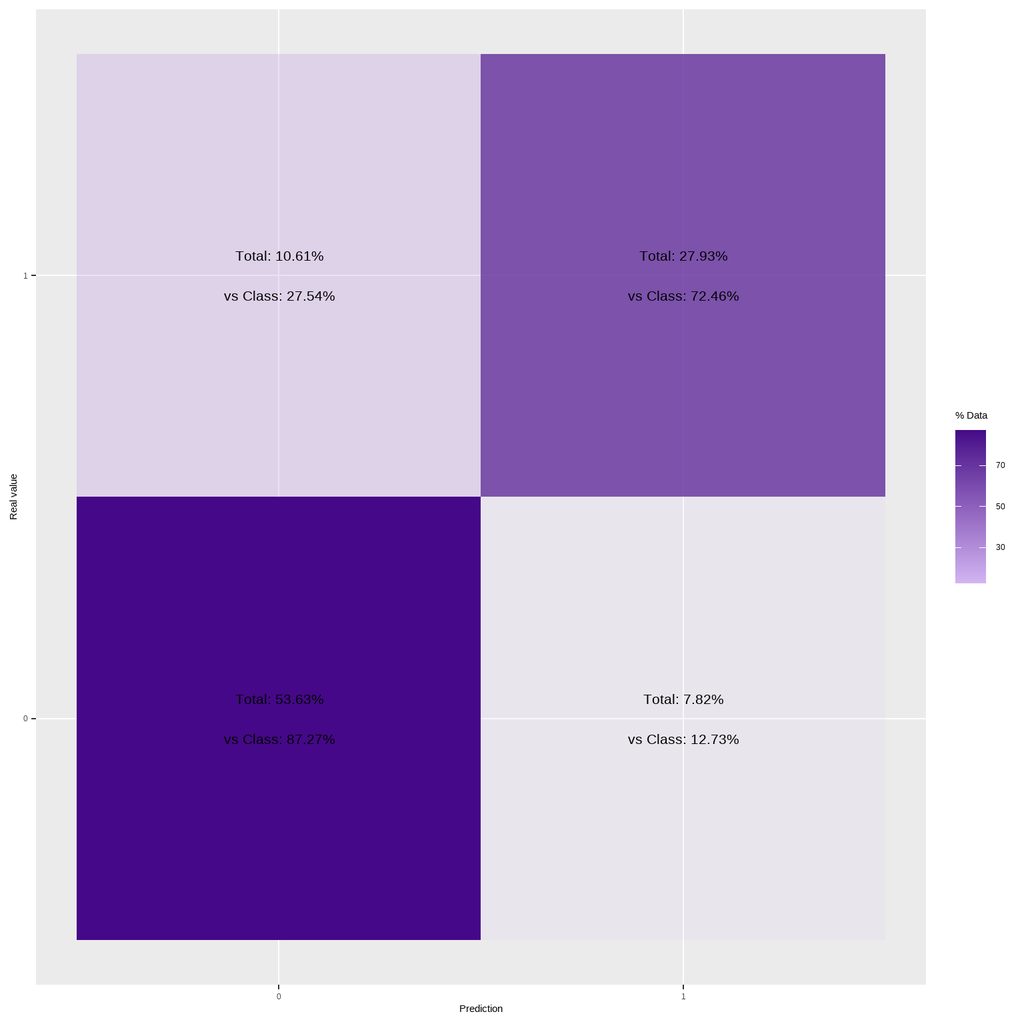

```r
# Expanding columns for use in the graph
confmat_titanic_train_test_ampliada <-
  confmat_titanic_train_test %>%
  group_by(Truth) %>%
  mutate(class = sum(n), porc_class = round(100 * n / class, 2)) %>%
  ungroup()

# Visualized confusion matrix
ggplot(data = confmat_titanic_train_test_ampliada,
       aes(x = Prediction, y = Truth,
           fill = porc_class, alpha = porc_class)) +
  geom_tile() +
  scale_fill_gradient(low = "#D2B5F2", high = "#450888") +
  geom_text(aes(label = glue("Total: {round(100 * n / sum(n), 2)}%
                             vs Class: {porc_class}%")),
            colour = "black", alpha = 1, size = 5.5,
            show.legend = FALSE) +
  labs(x = "Prediction", y = "Real value", fill = "% Data") +
  guides(alpha = "none") +
  scale_color_economist()
```

The ROC curve is calculated for the arbitrary model:

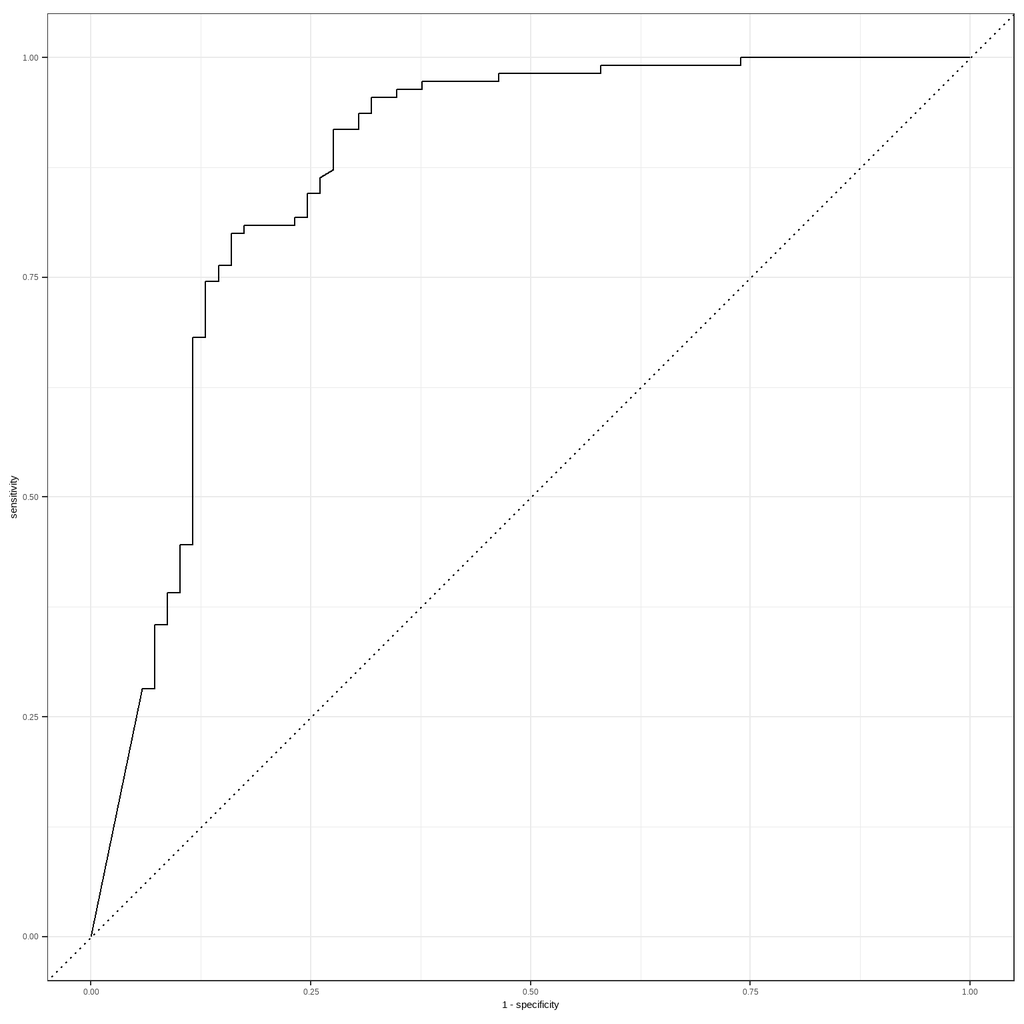

```r
# ROC Curve: actual vs probability of 1
roc_curve <- prob_titanic_train_test %>% roc_curve(truth = Survived, .pred_0)
roc_curve %>% autoplot()
```

```r
# Area under the curve
auc <- prob_titanic_train_test %>% roc_auc(truth = Survived, .pred_0)
auc <- auc %>% pull(.estimate)
auc
```

```
## [1] 0.8694993
```

## 3.2 Accuracy, sensitivity, specificity and ROC AUC.

Accuracy: 81.56% of the predictions made by the model are correct.

Sensitivity: 87.27% of positive instances were correctly identified.

Specificity: 72.46% of negative instances were correctly identified.

ROC Curve: The area under the ROC curve value is 0.869, suggesting that the model has good ability to distinguish between positive and negative classes.

```r
# Multiple metrics
multi_metric <- metric_set(accuracy, sensitivity, specificity, roc_auc)
metrics <-
  prob_titanic_train_test %>%
  multi_metric(truth = Survived, estimate = .pred_class, .pred_0)
acc <- metrics %>% filter(.metric == "accuracy") %>% pull(.estimate)
metrics
```

```
## # A tibble: 4 × 3
##   .metric     .estimator .estimate
##   <chr>       <chr>          <dbl>
## 1 accuracy    binary         0.816
## 2 sensitivity binary         0.873
## 3 specificity binary         0.725
## 4 roc_auc     binary         0.869
```

Below is the representation of the ROC curve in a graph:

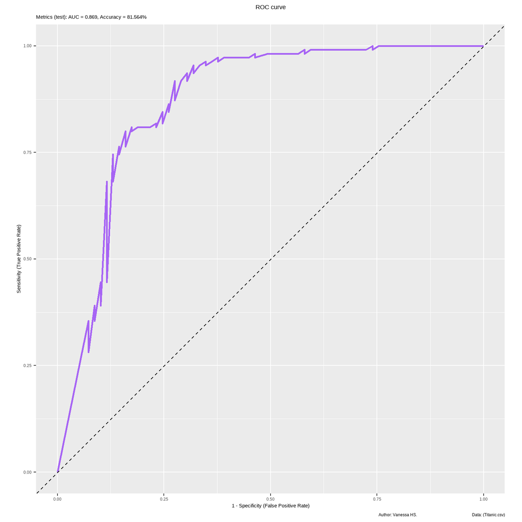

```r
# ROC curve
ggplot(roc_curve, aes(x = 1 - specificity, y = sensitivity)) +
  geom_line(lwd = 1, alpha = 0.85, color = "#9B4CF5") +
  geom_abline(lty = 2) +
  coord_equal() +
  labs(x = "1 - Specificity (False Positive Rate)",
       y = "Sensitivity (True Positive Rate)",
       title = "ROC curve",
       subtitle = glue("Metrics (test): AUC = {round(auc, 3)}, Accuracy = {round(100 * acc, 3)}%"),
       caption =
         paste0("Author: Vanessa HS.                                                      ",
                "Data: (Titanic.csv)")) +
  theme(plot.title = element_text(hjust = 0.5))
```

The previous model was built with a specification of 10 neighbors in the k-nearest neighbors (k-NN) algorithm. Now, we proceed to let R determine the optimal number of neighbors to use.

## 3.3 Tuning

In this step, R will carry out automatic selection of the optimal number of neighbors, the best weight, and the best distance for the k-NN algorithm. Then, the same previously created workflow is used. Lastly, the parameters to be optimized will be those of the workflow used earlier.

Workflow Summary:

```r
# Tuned model
knn_model <-
  nearest_neighbor(mode = "classification",
                   neighbors = tune("k"),
                   weight_func = tune("weight"),
                   dist_power = tune("dist")) %>%
  set_engine("kknn")

# Workflow
titanic_wflow <-
  workflow() %>%
  add_recipe(receta_titanic) %>%
  add_model(knn_model)
titanic_wflow
```

```
## ══ Workflow ════════════════════════════════════════════════════════════════════
## Preprocessor: Recipe
## Model: nearest_neighbor()
##
## ── Preprocessor ────────────────────────────────────────────────────────────────
## 7 Recipe Steps
##
## • step_mutate()
## • step_mutate()
## • step_impute_median()
## • step_impute_mode()
## • step_rm()
## • step_range()
## • step_dummy()
##
## ── Model ───────────────────────────────────────────────────────────────────────
## K-Nearest Neighbor Model Specification (classification)
##
## Main Arguments:
##   neighbors = tune("k")
##   weight_func = tune("weight")
##   dist_power = tune("dist")
##
## Computational engine: kknn
```

```r
# Parameters to optimize
param <- parameters(titanic_wflow)
param$object
```

```
## [[1]]
## # Nearest Neighbors (quantitative)
## Range: [1, 15]
##
## [[2]]
## Distance Weighting Function  (qualitative)
## 'rectangular', 'triangular', 'epanechnikov', 'biweight', 'triweight', 'cos', ...
##
## [[3]]
## Minkowski Distance Order (quantitative)
## Range: [0.1, 2]
```

## 3.4 Parameter Grid

A grid is created that includes the values among which the selection should be made.

```r
# Parameters grid
grid_knn <-
  parameters(titanic_wflow) %>%
  # Update
  update(k = neighbors(range = c(5, 45)), #k-neighbors range from 5 to 45
         weight = weight_func(values = c("inv", "gaussian")),
         dist = dist_power(range = c(0.5, 2))) %>% #distance 0.5 & 2
  grid_regular(levels = 4) #dividing from 5 to 45 in 4 levels
grid_knn
```

```
## # A tibble: 32 × 3
##        k weight    dist
##    <int> <chr>    <dbl>
##  1     5 inv        0.5
##  2    18 inv        0.5
##  3    31 inv        0.5
##  4    45 inv        0.5
##  5     5 gaussian   0.5
##  6    18 gaussian   0.5
##  7    31 gaussian   0.5
##  8    45 gaussian   0.5
##  9     5 inv        1
## 10    18 inv        1
## # ℹ 22 more rows
```

## 3.5 Cross-validation

Cross-validation is performed by dividing the model into 10 equal parts, and then training and evaluating it 10 times, each time using a different fold as the test set and the remaining as the training set. The aim is to maximize the model’s efficiency and to help detect overfitting or underfitting problems by evaluating the model’s performance on multiple test datasets.

```r
# Cross-validation
folds <- vfold_cv(titanic_train_train, v = 10, strata = Survived)
folds
```

```
## #  10-fold cross-validation using stratification
## # A tibble: 10 × 2
##    splits           id
##    <list>           <chr>
##  1 <split [640/72]> Fold01
##  2 <split [640/72]> Fold02
##  3 <split [640/72]> Fold03
##  4 <split [641/71]> Fold04
##  5 <split [641/71]> Fold05
##  6 <split [641/71]> Fold06
##  7 <split [641/71]> Fold07
##  8 <split [641/71]> Fold08
##  9 <split [641/71]> Fold09
## 10 <split [642/70]> Fold10
```

```r
# Testing all models using a validation set
titanic_knn_fit_tune <-
  titanic_wflow %>%
  tune_grid(resamples = folds, grid = grid_knn,
            control = control_grid(verbose = TRUE),
            metrics = multi_metric)
titanic_knn_fit_tune
```

```
## # Tuning results
## # 10-fold cross-validation using stratification
## # A tibble: 10 × 4
##    splits           id     .metrics           .notes
##    <list>           <chr>  <list>             <list>
##  1 <split [640/72]> Fold01 <tibble [128 × 7]> <tibble [0 × 3]>
##  2 <split [640/72]> Fold02 <tibble [128 × 7]> <tibble [0 × 3]>
##  3 <split [640/72]> Fold03 <tibble [128 × 7]> <tibble [0 × 3]>
##  4 <split [641/71]> Fold04 <tibble [128 × 7]> <tibble [0 × 3]>
##  5 <split [641/71]> Fold05 <tibble [128 × 7]> <tibble [0 × 3]>
##  6 <split [641/71]> Fold06 <tibble [128 × 7]> <tibble [0 × 3]>
##  7 <split [641/71]> Fold07 <tibble [128 × 7]> <tibble [0 × 3]>
##  8 <split [641/71]> Fold08 <tibble [128 × 7]> <tibble [0 × 3]>
##  9 <split [641/71]> Fold09 <tibble [128 × 7]> <tibble [0 × 3]>
## 10 <split [642/70]> Fold10 <tibble [128 × 7]> <tibble [0 × 3]>
```

```r
# Metrics
titanic_knn_fit_tune %>% collect_metrics()
```

```
## # A tibble: 128 × 9
##        k weight    dist .metric     .estimator  mean     n std_err .config
##    <int> <chr>    <dbl> <chr>       <chr>      <dbl> <int>   <dbl> <chr>
##  1     5 gaussian   0.5 accuracy    binary     0.806    10  0.0158 Preprocessor…
##  2     5 gaussian   0.5 roc_auc     binary     0.850    10  0.0155 Preprocessor…
##  3     5 gaussian   0.5 sensitivity binary     0.852    10  0.0256 Preprocessor…
##  4     5 gaussian   0.5 specificity binary     0.733    10  0.0308 Preprocessor…
##  5    18 gaussian   0.5 accuracy    binary     0.798    10  0.0120 Preprocessor…
##  6    18 gaussian   0.5 roc_auc     binary     0.861    10  0.0144 Preprocessor…
##  7    18 gaussian   0.5 sensitivity binary     0.884    10  0.0218 Preprocessor…
##  8    18 gaussian   0.5 specificity binary     0.659    10  0.0214 Preprocessor…
##  9    31 gaussian   0.5 accuracy    binary     0.808    10  0.0118 Preprocessor…
## 10    31 gaussian   0.5 roc_auc     binary     0.863    10  0.0138 Preprocessor…
## # ℹ 118 more rows
```

Due to the large number of results, the top 5 in accuracy and ROC are selected:

```r
# Best model based on Accuracy & ROC
titanic_knn_fit_tune %>% show_best("accuracy")
```

```
## # A tibble: 5 × 9
##       k weight    dist .metric  .estimator  mean     n std_err .config
##   <int> <chr>    <dbl> <chr>    <chr>      <dbl> <int>   <dbl> <chr>
## 1    31 gaussian   0.5 accuracy binary     0.808    10  0.0118 Preprocessor1_Mo…
## 2     5 gaussian   0.5 accuracy binary     0.806    10  0.0158 Preprocessor1_Mo…
## 3    31 gaussian   1   accuracy binary     0.805    10  0.0129 Preprocessor1_Mo…
## 4     5 gaussian   1   accuracy binary     0.801    10  0.0125 Preprocessor1_Mo…
## 5     5 gaussian   1.5 accuracy binary     0.801    10  0.0108 Preprocessor1_Mo…
```

```r
titanic_knn_fit_tune %>% show_best("roc_auc")
```

```
## # A tibble: 5 × 9
##       k weight    dist .metric .estimator  mean     n std_err .config
##   <int> <chr>    <dbl> <chr>   <chr>      <dbl> <int>   <dbl> <chr>
## 1    31 gaussian   1.5 roc_auc binary     0.863    10  0.0132 Preprocessor1_Mod…
## 2    31 gaussian   0.5 roc_auc binary     0.863    10  0.0138 Preprocessor1_Mod…
## 3    31 gaussian   2   roc_auc binary     0.862    10  0.0129 Preprocessor1_Mod…
## 4    31 gaussian   1   roc_auc binary     0.862    10  0.0131 Preprocessor1_Mod…
## 5    18 gaussian   0.5 roc_auc binary     0.861    10  0.0144 Preprocessor1_Mod…
```

Graph with the results:

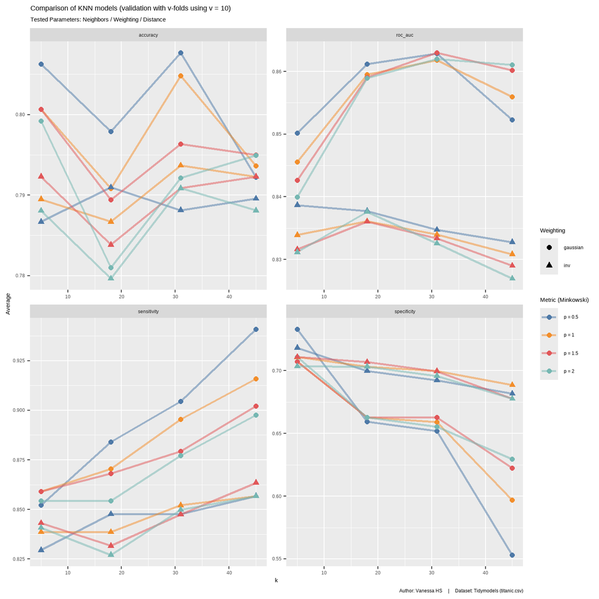

```r
# Visual comparison
titanic_knn_fit_tune %>%
  collect_metrics() %>%
  mutate(dist = factor(dist), weight = factor(weight)) %>%
  ggplot(aes(k, mean, color = dist, shape = weight)) +
  geom_line(size = 1, alpha = 0.5) +
  geom_point(size = 2) +
  # 2 rows(accurancy, roc_auc)
  facet_wrap(~.metric, scales = "free", nrow = 2) +
  scale_color_tableau(labels = glue("p = {c(0.5, 1, 1.5, 2)}")) +
  labs(y = "Average",
       color = "Metric (Minkowski)",
       shape = "Weighting",
       title = glue("Comparison of KNN models (validation with v-folds using v = {nrow(folds)})"),
       subtitle = "Tested Parameters: Neighbors / Weighting / Distance",
       caption =
         paste0("Author: Vanessa HS     |     ",
                "Dataset: Tidymodels (titanic.csv)"))
```

```r
# Best according to Accuracy
best_knn <- titanic_knn_fit_tune %>%
  select_best("accuracy")
best_knn
```

```
## # A tibble: 1 × 4
##       k weight    dist .config
##   <int> <chr>    <dbl> <chr>
## 1    31 gaussian   0.5 Preprocessor1_Model03
```

```r
best_knn_std_error <- titanic_knn_fit_tune %>%
  select_by_one_std_err(metric = "accuracy", k)

# End flow with the last one selected by standard error
final_wf <-
  titanic_wflow %>%
  finalize_workflow(best_knn_std_error)
final_wf
```

```
## ══ Workflow ════════════════════════════════════════════════════════════════════
## Preprocessor: Recipe
## Model: nearest_neighbor()
##
## ── Preprocessor ────────────────────────────────────────────────────────────────
## 7 Recipe Steps
##
## • step_mutate()
## • step_mutate()
## • step_impute_median()
## • step_impute_mode()
## • step_rm()
## • step_range()
## • step_dummy()
##
## ── Model ───────────────────────────────────────────────────────────────────────
## K-Nearest Neighbor Model Specification (classification)
##
## Main Arguments:
##   neighbors = 5
##   weight_func = gaussian
##   dist_power = 0.5
##
## Computational engine: kknn
```

```r
# Adjustment with the selected model in validation
final_fit <-
  final_wf %>%
  last_fit(titanic_split)
final_fit
```

```
## # Resampling results
## # Manual resampling
## # A tibble: 1 × 6
##   splits            id               .metrics .notes   .predictions .workflow
##   <list>            <chr>            <list>   <list>   <list>       <list>
## 1 <split [712/179]> train/test split <tibble> <tibble> <tibble>     <workflow>
```

```r
# Calculation of metrics on test
final_fit %>% collect_metrics()
```

```
## # A tibble: 2 × 4
##   .metric  .estimator .estimate .config
##   <chr>    <chr>          <dbl> <chr>
## 1 accuracy binary         0.832 Preprocessor1_Model1
## 2 roc_auc  binary         0.885 Preprocessor1_Model1
```

```r
# Final workflow
extract_workflow(final_fit)
```

```
## ══ Workflow [trained] ══════════════════════════════════════════════════════════
## Preprocessor: Recipe
## Model: nearest_neighbor()
##
## ── Preprocessor ────────────────────────────────────────────────────────────────
## 7 Recipe Steps
##
## • step_mutate()
## • step_mutate()
## • step_impute_median()
## • step_impute_mode()
## • step_rm()
## • step_range()
## • step_dummy()
##
## ── Model ───────────────────────────────────────────────────────────────────────
##
## Call:
## kknn::train.kknn(formula = ..y ~ ., data = data, ks = min_rows(5L,     data, 5), distance = ~0.5, kernel = ~"gaussian")
##
## Type of response variable: nominal
## Minimal misclassification: 0.1797753
## Best kernel: gaussian
## Best k: 5
```

Now we can construct the top 3 final models.

# 4 Final KNN models

```r
# 3 models
knn_model_1 <- titanic_wflow %>%
  update_model(knn_model %>% set_args(neighbors = 31,
                                      weight_func = "gaussian",
                                      dist_power = 0.5))

knn_model_2 <- titanic_wflow %>%
  update_model(knn_model %>% set_args(neighbors = 5,
                                      weight_func = "gaussian",
                                      dist_power = 0.5))

knn_model_3 <- titanic_wflow %>%
  update_model(knn_model %>% set_args(neighbors = 31,
                                      weight_func = "gaussian",
                                      dist_power = 1))

# Application of flows
knn_fit_1 <- knn_model_1 %>% fit(data = titanic_train_train)
knn_fit_2 <- knn_model_2 %>% fit(data = titanic_train_train)
knn_fit_3 <- knn_model_3 %>% fit(data = titanic_train_train)


# Saving the models
models <- list("knn_1" = knn_fit_1, "knn_2" = knn_fit_2,
               "knn_3" = knn_fit_3)
```

Below are the predictions of the 3 models, where it is observed that the area under the AUC curve is wide, indicating that the probability of the models correctly classifying whether a crew member survived or not is high.

```r
pred_probs <- imap_dfr(models, augment,
                       new_data = titanic_train_test, .id = "model")

# 'Survived' y the predictions
pred_probs <- pred_probs %>%
  select(model, Survived, .pred_class, .pred_0, .pred_1)
pred_probs
```

```
## # A tibble: 537 × 5
##    model Survived .pred_class .pred_0 .pred_1
##    <chr> <fct>    <fct>         <dbl>   <dbl>
##  1 knn_1 1        0             0.582  0.418
##  2 knn_1 0        0             0.926  0.0738
##  3 knn_1 0        0             0.514  0.486
##  4 knn_1 0        0             0.874  0.126
##  5 knn_1 1        0             0.932  0.0677
##  6 knn_1 1        1             0.362  0.638
##  7 knn_1 0        0             0.607  0.393
##  8 knn_1 0        0             0.803  0.197
##  9 knn_1 1        1             0.394  0.606
## 10 knn_1 0        0             0.778  0.222
## # ℹ 527 more rows
```

```r
# Joint metrics
metrics <-
  pred_probs %>%
  group_by(model) %>%
  multi_metric(truth = Survived, estimate = .pred_class, .pred_0)
metrics
```

```
## # A tibble: 12 × 4
##    model .metric     .estimator .estimate
##    <chr> <chr>       <chr>          <dbl>
##  1 knn_1 accuracy    binary         0.844
##  2 knn_2 accuracy    binary         0.832
##  3 knn_3 accuracy    binary         0.844
##  4 knn_1 sensitivity binary         0.927
##  5 knn_2 sensitivity binary         0.891
##  6 knn_3 sensitivity binary         0.927
##  7 knn_1 specificity binary         0.710
##  8 knn_2 specificity binary         0.739
##  9 knn_3 specificity binary         0.710
## 10 knn_1 roc_auc     binary         0.872
## 11 knn_2 roc_auc     binary         0.885
## 12 knn_3 roc_auc     binary         0.875
```

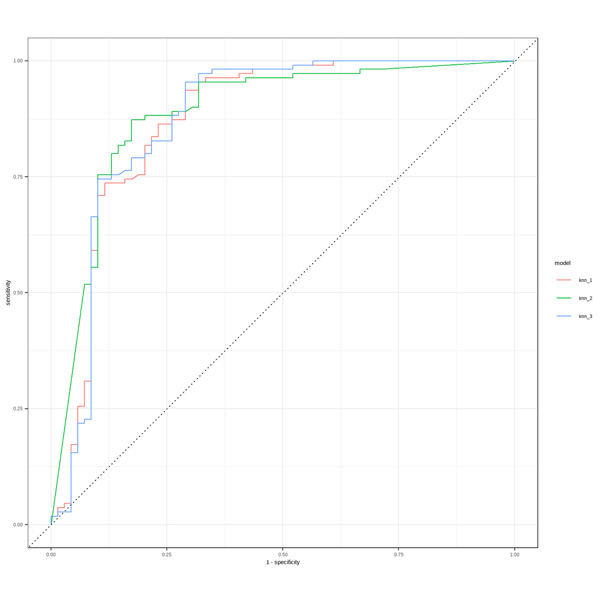

```r
# ROC curves
roc_curves <-
  pred_probs %>% group_by(model) %>%
  roc_curve(Survived, .pred_0)
roc_curves %>% autoplot()
```

## 4.1 Files for Kaggle and Results

The results of the 3 KNN models are saved to upload them to the Kaggle website in order to see the rate of correctly classified instances.

```r
# Saving the results
knn1 <- augment(knn_fit_1, titanic_test)
knn2 <- augment(knn_fit_2, titanic_test)
knn3 <- augment(knn_fit_3, titanic_test)

knn1 <- knn1 %>% mutate(Survived = .pred_class)
knn2 <- knn2 %>% mutate(Survived = .pred_class)
knn3 <- knn3 %>% mutate(Survived = .pred_class)

knn1 <- knn1 %>% select(c(PassengerId, Survived))
knn2 <- knn2 %>% select(c(PassengerId, Survived))
knn3 <- knn3 %>% select(c(PassengerId, Survived))

write.csv(knn1, "knn1.csv", row.names = F)
write.csv(knn2, "knn2.csv", row.names = F)
write.csv(knn3, "knn3.csv", row.names = F)
```

## 4.2 Final results

The results obtained on Kaggle are as follows:

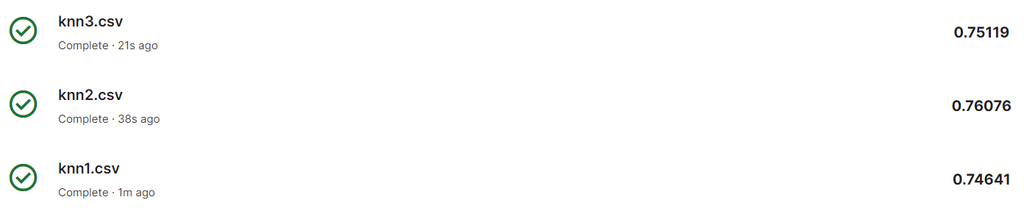

```r
# Image
knitr::include_graphics("C:/Users/vanny/OneDrive/Escritorio/Portfolio/kaggle__titanicKNN_results.png")
```